# storytime

# Introduction

The northern goshawk is a forest-dwelling raptor with a wide distribution and generalist diet. However, the number and identity of key prey species varies across its range, with consequences for demographics. For such an adaptable predator, the identity and influence of key prey species on population demographics may be specific to each population.

Here we describe goshawk diet at the nest during the breeding season. We evaluate whether landscape characteristics are correlated with variation in breeding season diet across this ecologically diverse region. Finally, we explore whether occupancy and reproductive success vary with diet and landscape characteristics. Addressing these fundamental knowledge gaps will assist in improving existing forest management strategies.

In the 2020 field season, we installed nest cameras at 8 sites, collected pellets & prey remains for 5+ sites, and deployed transmitters at 6 sites.

# Goshawk diet

## Diet methods

Goshawk diet was assessed using three methods: egested pellets, prey remains, and nest cameras.

### Pellets

A total of 71 prey items were identified from egested pellets collected at 12 sites in 2019 and 2020 (more data from the 2020 season still to come). Most sites had only 1-3 items identified from pellets, though some had 10 or more items identified.

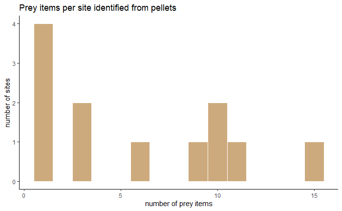

48% of items could be identified to genus or better, and no item could not at least be identified to class. 4 different species were identified:

| binomial | common |
| --- | --- |
| Junco hyemalis | dark-eyed junco |
| Colaptes auratus | northern flicker |
| Sphyrapicus ruber | red-breasted sapsucker |
| Tamiasciurus douglasii | douglas squirrel |

### Remains

An additional 68 prey items were identified from prey remains collected from 18 sites in 2019 and 2020 (more data from the 2020 season still to come).

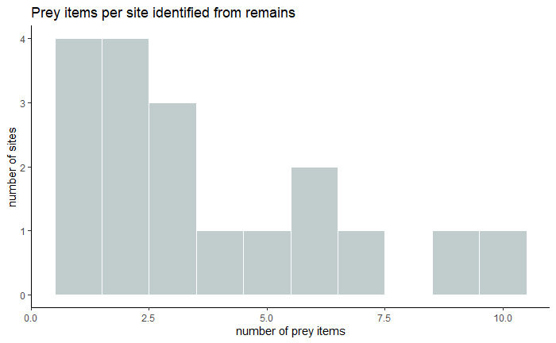

49% of items could be identified to genus or better, and only 1 item could not be identified at least to class. 16 different species were identified:

| binomial | common |
| --- | --- |
| Larus canus | mew gull |
| Patagoienas fasciata | band-tailed pigeon |
| Corvus caurinus | northwestern crow |
| Cyanocitta stelleri | steller’s jay |
| Pipilo maculatus | spotted towhee |
| Bonasa umbellus | ruffed grouse |
| Dendragapus fulignosus | sooty grouse |
| Ixoreus naevius | varied thrush |
| Colaptes auratus | northern flicker |
| Accipiter striatus | sharp-shinned hawk |
| Anas sp | duck |
| Strix varia | barred owl |
| Lepus americanus | snowshoe hare |
| Neotoma cinerea | bushy-tailed woodrat |
| Tamiasciurus douglasii | douglas squirrel |
| Tamiasciurus hudsonicus | red squirrel |

### Combined pellets and remains

Combining pellets and remains gives a total of 139 physical prey items from 19 sites.

Most sites had only 1-5 items identified from pellets and remains, though some had more than 20 items identified.

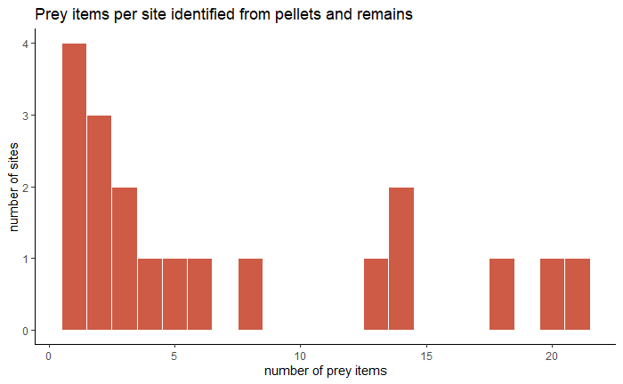

### Cameras

From cameras, 554 prey items were identified from photographs taken at 6 sites 2019 (more data from the 2020 season still to come). Nests had between 37 and 143 (mean = 92) items identified.

| binomial | common |
| --- | --- |
| Patagoienas fasciata | band-tailed pigeon |
| Cyanocitta stelleri | steller’s jay |
| Perisoreus canadensis | gray jay |
| Bonasa umbellus | ruffed grouse |
| Dendragapus fulignosus | sooty grouse |
| Catharus ustulatus | swainson’s thrush |
| Ixoreus naevius | varied thrush |
| Turdus migratorius | american robin |
| Lepus americanus | snowshoe hare |
| Rattus sp | rat |
| Neotoma cinerea | bushy-tailed woodrat |
| Tamiasciurus douglasii | douglas squirrel |
| Tamiasciurus hudsonicus | red squirrel |
| Glaucomys sabrinus | flying squirrel |
| Neotamias sp | chipmunk |
| Myotis sp | bat |

### Comparison of methods

Prey remains greatly overestimated avian prey relative to pellets or cameras, causing the combined pellets and remains data to be skewed. Pellets alone produced broadly similar estimates of mammalian and squirrel biomass to cameras.

While counts and biomass are broadly similar, counts generally overestimate birds relative to biomass.

Morisita’s index of overlap:

```
            remains    cameras    pellets
cameras  0.86651868
pellets  0.87885481 0.04052104
combined 0.45921499 0.13684025 0.16646090
```

To show visually how different the species list is for each data source:

[interactive chart not shown]

## Diet quantification

Based on data from pellets alone, mammals accounted for 62% of prey items (77% by biomass) and birds accounted for 38% of items (23% by biomass). The most commonly identified prey categories were squirrel (37% by count, 53% by biomass) and other birds (37% by count, 23% by biomass).

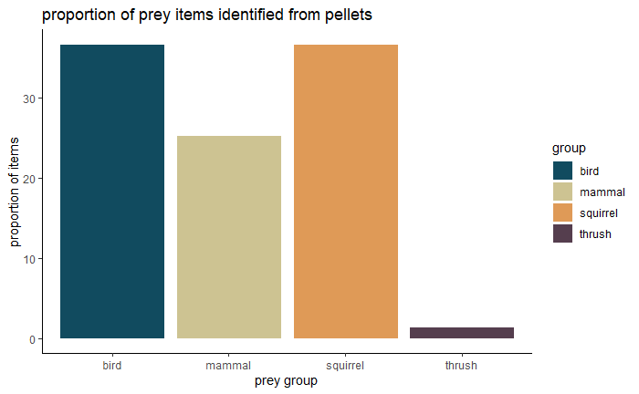

Based on data from pellets and remains combined, mammals accounted for 38% of prey items (37% by biomass) and birds accounted for 61% of items (61% by biomass). The most commonly identified prey category was other birds (50% by count, 53% by biomass). Squirrel (20% count, 14% biomass), other mammals (14% count, 7% biomass), and thrushes (5% count, 1% biomass) also made up >5% of items. While hare did not make up a significant proportion of counts (4%), it did make up a large proportion of biomass (16%).

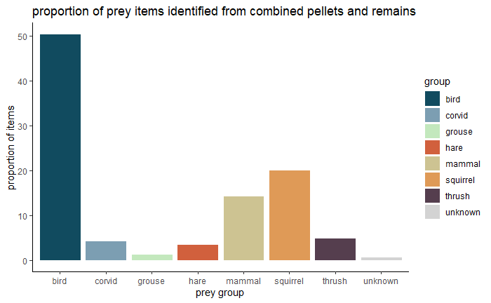

Based on data from nest cameras, mammals accounted for 71% of prey items (84% by biomass) and birds accounted for 19% of items (13% by biomass). The most commonly identified prey categories were squirrel (60% by count, 71% by biomass). Thrushes (1% biomass), other mammals (7% biomass), and unidentified items (2% biomass) each made up approximately 10% of the items.

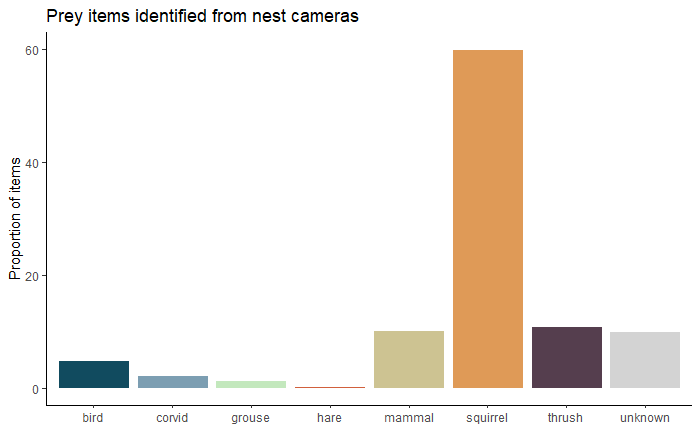

Based on items identified to species from camera data, the mean diet diversity for the entire study area was 0.44 (range = 0.08-0.66).

Based on items prey groupings from camera items identified at least to class, the mean diet diversity for the entire study area was 0.48 (range = 0.3-0.71).

# Diet consequences

## Productivity

Mammals generally, and squirrels (genus *Tamiasciurus*) in particular, are presumed to be an important factor in goshawk breeding success. Here are some linear models testing whether that presumption (based on biomass from camera data) is correct.

Productivity data is only available for the 6 camera sites in 2019, but will (hopefully) also be available for the 8 camera sites in 2020.

| r.squared | adj.r.squared | sigma | statistic | p.value | df | variable |
| --- | --- | --- | --- | --- | --- | --- |
| 0.4237368 | 0.2796711 | 0.8765563 | 2.941273 | 0.1614898 | 2 | diet diversity |
| 0.4955661 | 0.3694577 | 0.8201088 | 3.929682 | 0.1184836 | 2 | proportion mammal |
| 0.7144896 | 0.6431119 | 0.6169932 | 10.009995 | 0.0340578 | 2 | proportion.squirrel |

Squirrels appear to be important for high productivity, albeit based on a small sample size.

## Occupancy

| term | estimate | std.error | statistic | p.value |
| --- | --- | --- | --- | --- |
| (Intercept) | 1.9802832 | 6.819126 | 0.2904013 | 0.7715092 |
| proportion.squirrel | -0.2509984 | 9.035642 | -0.0277787 | 0.9778387 |

Albeit based on a small sample size, diet diversity and proportion squirrel do not appear to impact occupancy. This may be a bit misleading, since it assumes diet remains constant through time.

# Landscape

## Zones: coastal & transition

FLNR has delineated a transition zone composed of drier ecosystem types intermediate between the wet coastal rainforest and the arid interior forests. These ecosystem differences may be reflected in goshawk diet between the two zones.

Of the 6 camera sites from 2019, 2 sites are categorized as coastal, and 4 as transition.

Overall, the two zones do differ in the prey categories present when using camera data. Chi-squared test using camera data:

```
    Pearson's Chi-squared test with simulated p-value (based on 2000 replicates)

data:  freq.camera
X-squared = 19.725, df = NA, p-value = 0.004498
```

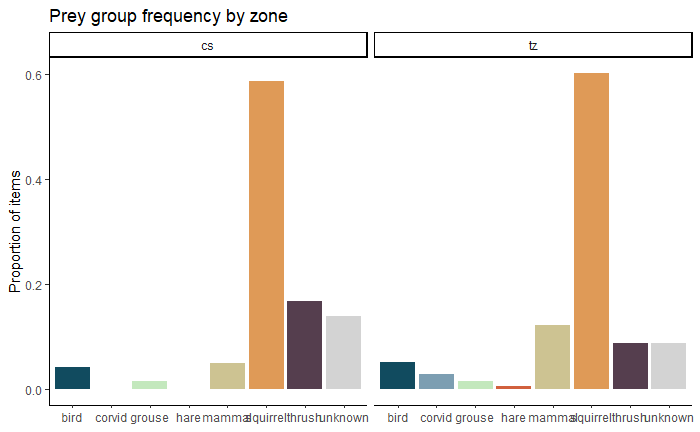

However, the zones do not appear different when using pellets only or combined pellets and remains. Chi-squared test using combined pellets and remains:

```
    Pearson's Chi-squared test with simulated p-value (based on 2000 replicates)

data:  freq.combined
X-squared = 12.656, df = NA, p-value = 0.05347
```

And chi-squared test using pellets only:

```
    Pearson's Chi-squared test with simulated p-value (based on 2000 replicates)

data:  freq.pellets
X-squared = 1.9778, df = NA, p-value = 0.6807
```

When looking closer at the differences between the zones in the camera data, the differences seem to lie in certain birds and other mammals, but not in groups that are predicted to be important (mostly squirrels).

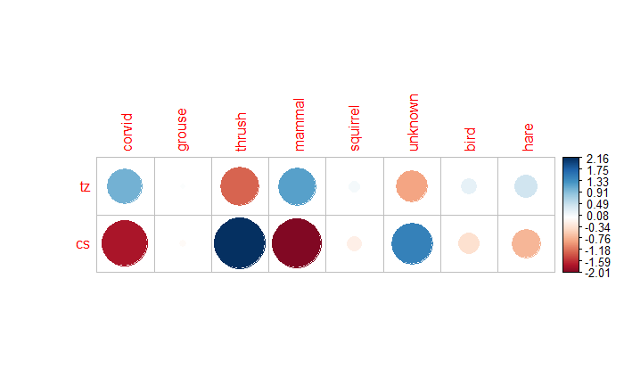

Numbers of squirrels (the dominant prey item) and grouse and hare (less common but high-value prey items) are not enormously different between the zones. But birds in the coastal zone consume much more thrush than expected, and much less assorted other mammals than expected.

## Forest characteristics

At scales smaller than the broad coastal and transition zones, forest characteristics may influence diet diversity, amount of squirrel in the diet, or other diet variables. Forest characteristics were described in several contexts:

- ecological zone
- vegetation composition and age
- goshawk foraging suitability

From these, an array of metrics was calculated:

- Landscape composition
  - proportion older forest
  - proportion suitable habitat
  - amount canopy cover*
- Configuration
  - edge density of landcover
  - edge density of HSI
  - edge density of shrub/open space
  - edge density of suitable habitat
- Aggregation
  - contagion of landcover
  - contagion of HSI
- Diversity
  - Simpson’s diversity index (forest type)
  - Simpson’s diversity index (landcover)
  - Simpson’s evenness index (landcover)
  - patch richness density (landcover)

Each metric was calculated at four nested spatial scales:

| size | area | radius |
| --- | --- | --- |
| PFA | 60.00 | 437.0194 |
| breeding area | 200.00 | 797.8846 |
| home range | 3800.00 | 3477.8982 |
| maximum range | 32902.97 | 10233.9341 |

A series of univariate models were run using camera data to determine whether any of these metrics influence diet diversity or the proportion of squirrel biomass in the diet.

Only one variable was found to be significant at the 0.05 level for diet diversity, proportion high canopy cover:

| variable | PFA | breeding area | home range | maximum range |
| --- | --- | --- | --- | --- |
| forest type diversity | 0.27 | 0.28 | 0.32 | 0.07 |
| proportion older forest | 0.92 | 0.86 | 0.39 | 0.07 |
| landcover edge density | 0.96 | 0.92 | 0.8 | 0.43 |
| landcover contagion | 0.23 | 0.85 | 0.51 | 0.45 |
| landcover diversity | 0.93 | 0.81 | 0.53 | 0.29 |
| landcover evenness | 0.24 | 0.85 | 0.51 | 0.31 |
| landcover richness | 0.62 | 0.46 | 0.84 | 0.92 |
| gap edge density | 0.88 | 0.66 | 0.41 | 0.14 |
| proportion high canopy cover | 0.93 | 0.87 | 0.33 | 0.04 * |
| hsi edge density | 0.98 | 0.97 | 0.91 | 0.33 |
| hsi contagion | 0.44 | 0.91 | 0.45 | 0.72 |
| proportion suitable | 0.91 | 0.61 | 0.28 | 0.24 |
| suitable habitat edge density | 0.94 | 0.73 | 0.67 | 0.61 |

However, four variables were found to be significant at predicting proportion of squirrel biomass: landcover contagion, landcover diversity, landcover evenness, and proportion high canopy cover.

| variable | PFA | breeding area | home range | maximum range |
| --- | --- | --- | --- | --- |
| forest type diversity | 0.83 | 0.89 | 0.6 | 0.63 |
| proportion older forest | 0.61 | 0.44 | 0.06 | 0.12 |
| landcover edge density | 0.27 | 0.23 | 0.52 | 0.72 |
| landcover contagion | 0.6 | 0.12 | 0.03 * | 0.18 |
| landcover diversity | 0.17 | 0.15 | 0.01 * | 0.14 |
| landcover evenness | 0.56 | 0.15 | 0.01 * | 0.15 |
| landcover richness | 0.26 | 0.09 | 0.14 | 0.8 |
| gap edge density | 0.68 | 0.7 | 0.65 | 0.56 |
| proportion high canopy cover | 0.93 | 0.87 | 0.33 | 0.04 * |
| hsi edge density | 0.7 | 0.58 | 0.65 | 0.68 |
| hsi contagion | 0.45 | 0.78 | 0.71 | 0.99 |
| proportion suitable | 0.61 | 0.33 | 0.06 | 0.27 |
| suitable habitat edge density | 0.66 | 0.4 | 0.25 | 0.67 |

- **Landcover contagion** is the probably that two given cells belong to type i and j. Measures both interspersion (are the different patch types mixed up randomly or do certain types always occur next to others), and dispersion (are all patches of a given types close together or really spread out).
- **Landcover diversity** is the probability that two types selected randomly will be different. Measures both richness and evenness.
- **Landcover evenness** is the distribution of area between different patch types.
- **Proportion high canopy cover** is the amount of the landscape covered by forest with at least 75% canopy closure, controlling for the total size of the landscape.

Then next step is to run multivariate models with different combinations of significant variables, but as some of these are highly correlated they will not go in the same models together.

# Landscape consequences

Given that landscape affects diet and diet has consequences for reproductive success, the next question is whether landscape directly affects reproductive success and site occupancy or only indirectly through the diet.

## Productivity

There doesn’t appear to be any difference in productivity between zones, using nest camera data.

At smaller scales, forest characteristics don’t seem to have any impact on productivity, either.

## Occupancy

If one zone, coastal or transition, represents a better overall habitat for goshawks, there could be a difference between them in site occupancy.

| term | estimate | std.error | statistic | p.value |
| --- | --- | --- | --- | --- |
| (Intercept) | 0.2769868 | 0.09670267 | 2.8643136 | 0.00417914 |
| zonetz | -0.1469337 | 0.14964429 | -0.9818862 | 0.32615593 |

However, that does not seem to be the case.

| variable | PFA | breeding area | home range | maximum range |
| --- | --- | --- | --- | --- |
| forest type diversity | 0.57 | 0.27 | 0.36 | 0.27 |
| proportion older forest | 0.15 | 0.33 | 0.27 | 0.13 |
| landcover edge density | 0.08 | 0.05 | 0.96 | 0.67 |
| landcover contagion | 0.08 | 0.14 | 0.24 | 0.19 |
| landcover diversity | 0.05 * | 0.2 | 0.05 * | 0.08 |
| landcover evenness | 0.08 | 0.21 | 0.05 | 0.07 |
| landcover richness | 0.52 | 0.92 | 0.04 * | 0.77 |
| gap edge density | 0 * | 0 * | 0.07 | 0.27 |
| high canopy cover | 0.67 | 0.3 | 0.45 | 0.98 |
| hsi edge density | 0.14 | 0.44 | 0.96 | 0.21 |
| hsi contagion | 0.15 | 0.76 | 0.95 | 0.41 |
| proportion suitable | 0 * | 0.17 | 0.18 | 0.47 |
| suitable habitat edge density | 0 * | 0.02 * | 0.61 | 0.03 * |